# Q3_projects_vs_time

Lisa Rosenthal

2023-09-18

# Question 3

For burn projects that took more than a week to wrap up: How well did the number of days for which thermal anomalies were detected corroborate with the number of days that burners indicated in their project reporting? How does the level of corroboration change as a burn project stretches out longer in time?

## Approach

For every day an activity occurs, assess if there was a VIIRS detection within its treatment polygon. Compare % of temporally correct detections to duration of activity.

## Prep data

Load VIIRS and CalMAPPER data. CalMapper polygons buffered with a radius of half the VIIRS resolution.

```r
# VIIRS fire detects
viirs <- read_rds(file.path(ref_path, 'VIIRS/CA_2020/viirs_nonAg.rds'))


# load up CalMAPPER data, created in Q1
CM_burn2020_buffered <- read_rds(file.path(ref_path, 'CalMAPPER/burnactivities_2020_buffered.rds'))
CM_trtIDs_buffered <- read_rds(file.path(ref_path, 'CalMAPPER/treatmentgeometries_2020_buffered.rds'))
```

Get VIIRS points that intersect with the polygons.

```r
# get the viirs points contained in the treatment polygons
viirs_t <- st_transform(viirs, st_crs(CM_burn2020_buffered))

# find those that intersect, do with each activity
viirs_int <- viirs_t %>%
  filter(CONFIDENCE != 'l') %>%
  st_intersection(CM_burn2020_buffered) %>%
  mutate(rowname = rownames(.),
         pointID = floor(as.numeric(rowname)),
         overlap_trts = grepl('\\.', rowname),
         .before = LATITUDE) %>%
  group_by(pointID) %>%
  mutate(overlap_trts = any(overlap_trts == T)) %>%
  ungroup()
#print(viirs_int %>% arrange(pointID), width = Inf)
```

For every activity, calculate if VIIRS points were detected during CalMAPPER activity. how many points were during the recorded activity? how many detected but outside the activity window?

```r
# each row is a viirs point that intersected a polygon. A single VIIRS point can appear >1 if it intersects more than one activity. Likewise, an activity can appear >1 if there are multiple VIIRS points intersecting it.
viirs_matches <- viirs_int %>%
  mutate(date_matches_CM = date >= ACTIVITY_START & date <= ACTIVITY_END,
         dateadj_matches_CM = date_adj >= ACTIVITY_START & date_adj <= ACTIVITY_END,
         .after = date)

# group by activity and calculate VIIRS detections overlapping it
mean(yday(viirs_matches$ACTIVITY_START[1]), yday(viirs_matches$ACTIVITY_END[1]))
```

```
## [1] 134
```

```r
matches_activitylevel <- viirs_matches %>%
  as_tibble() %>%
  mutate(CM_jday = (yday(ACTIVITY_START) + yday(ACTIVITY_END)) / 2) %>%
  group_by(AQ_ID, TREATMENT_ID, CM_jday) %>%
  summarise(duration = as.numeric(duration[1]),
            trt_acres = as.numeric(trt_acres[1]),
            unique_viirs_days = length(unique(date)),
            n_matching_dates = length(unique(date[date_matches_CM == T])),
            n_matching_dates_adj = length(unique(date_adj[dateadj_matches_CM == T])),
            viirs_jday = mean(unique(jday))
            ) %>%
  arrange(TREATMENT_ID) %>%
  ungroup
print(matches_activitylevel, width = Inf)
```

```
## # A tibble: 298 × 9
##     AQ_ID TREATMENT_ID CM_jday duration trt_acres unique_viirs_days
##     <int>        <dbl>   <dbl>    <dbl>     <dbl>             <int>
##  1  80444          344    73          9     124.                  3
##  2  66335          724    12.5       16     290.                  3
##  3  73962          724    54          9     290.                  3
##  4  80101          724    75         29     290.                  3
##  5  88346          724    95.5       10     290.                  3
##  6  96023          724   128          9     290.                  3
##  7 138913          724   217          1     290.                  3
##  8 146258          724   364          3     290.                  3
##  9 271791          724   274.       184     290.                  3
## 10  63462         1588    14          5      53.5                 1
##    n_matching_dates n_matching_dates_adj viirs_jday
##               <int>                <int>      <dbl>
##  1                0                    0      235
##  2                0                    0       81.3
##  3                1                    1       81.3
##  4                1                    1       81.3
##  5                0                    0       81.3
##  6                0                    0       81.3
##  7                0                    0       81.3
##  8                0                    0       81.3
##  9                0                    0       81.3
## 10                1                    1       16
## # ℹ 288 more rows
```

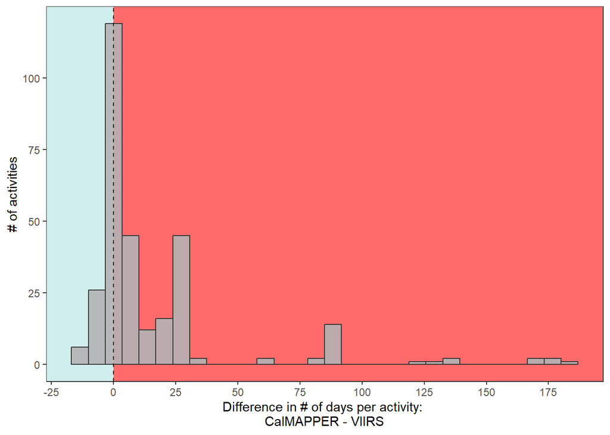

```r
# look at duration according to CM vs viirs
matches_activitylevel %>%
  mutate(diff = as.numeric(duration) - unique_viirs_days) %>%
  ggplot(aes(diff)) +
  geom_rect(aes(xmin = -Inf, xmax = 0, ymin = -Inf, ymax = Inf), fill = "lightcyan2") +
  geom_rect(aes(xmin = 0, xmax = Inf, ymin = -Inf, ymax = Inf), fill = "indianred1") +
  geom_histogram(color = 'grey20', fill = 'grey70', alpha = .9) +
  geom_vline(xintercept = 0, lty = 2) +
  labs(x = "Difference in # of days per activity: \nCalMAPPER - VIIRS",
       y = "# of activities") +
  scale_x_continuous(n.breaks = 10)
```

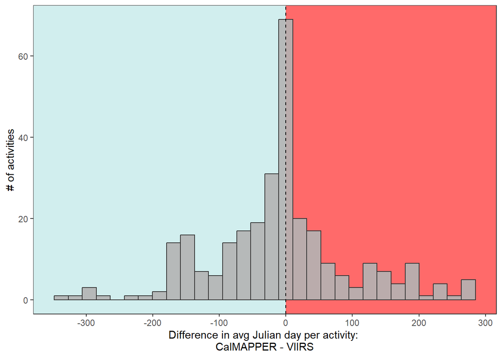

```r
# look at average julian day according to CM vs VIIRS
matches_activitylevel %>%
  mutate(diff = CM_jday  - viirs_jday) %>%
  ggplot(aes(diff)) +
  geom_rect(aes(xmin = -Inf, xmax = 0, ymin = -Inf, ymax = Inf), fill = "lightcyan2") +
  geom_rect(aes(xmin = 0, xmax = Inf, ymin = -Inf, ymax = Inf), fill = "indianred1") +
  geom_histogram(color = 'grey20', fill = 'grey70', alpha = .9) +
  geom_vline(xintercept = 0, lty = 2) +
  labs(x = "Difference in avg Julian day per activity: \nCalMAPPER - VIIRS",
       y = "# of activities") +
  scale_x_continuous(n.breaks = 10)
```

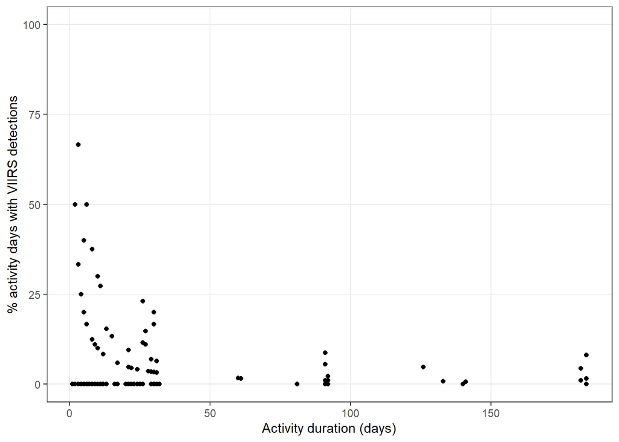

```r
# look at % of activity days with VIIRS detections vs. duration
ggplot(matches_activitylevel,
       aes(as.numeric(duration), 100 * n_matching_dates/as.numeric(duration))) +
  geom_point() +
  labs(x = 'Activity duration (days)',
       y = "% activity days with VIIRS detections") +
  scale_y_continuous(limits = c(0, 100))
```

```r
# # same thing as above but x-axis is activity size
# matches_activitylevel %>%
#   filter(n_matching_dates > 0 ) %>%
#   ggplot(aes(trt_acres, 100 * n_matching_dates/as.numeric(duration))) +
#   geom_point() +
#   labs(x = 'Polygon size (acres)',
#        y = "% activity days with VIIRS detections") +
#   scale_y_continuous(limits = c(0, 100)) +
#   facet_grid(~ duration <= 7)

# # probability of any VIIRS detections vs. duration
# ggplot(matches_activitylevel, aes(duration, as.numeric(n_matching_dates != 0))) +
#   geom_point(alpha = .2) +
#   geom_smooth(method="glm", method.args = list(family = "binomial")) +
#   labs(x = 'Activity duration (days)',
#        y = "Probability of any VIIRS detections")

# % of activities with no VIIRS detections on those days
mean(matches_activitylevel$n_matching_dates == 0)
```

```
## [1] 0.7147651
```

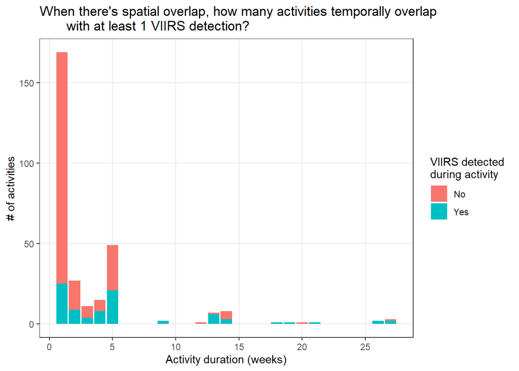

```r
# number of days spatially overlapping that do not temporally match
# i.e. the days with satellite detections without calMAPPER records
# --> false positives or missing calMAPPER records
matches_activitylevel %>%
  mutate(any_detection = as.numeric(n_matching_dates != 0),
         dur_class = cut(duration, breaks = seq(0, max(duration) + 7, by = 7),
                         labels = F)) %>%
  group_by(dur_class) %>%
  summarise(Yes = sum(any_detection),
            No = n() - Yes) %>%
  pivot_longer(-dur_class) %>%
  ggplot(aes(dur_class, value, group = name, fill = name)) +
  geom_col() +
  labs(x = "Activity duration (weeks)",
       y = "# of activities",
       fill = "VIIRS detected \nduring activity",
       title = "When there's spatial overlap, how many activities temporally overlap
       with at least 1 VIIRS detection?") +
  scale_x_continuous(n.breaks = 10)
```

Those were just the activities where VIIRS intersecting. how many activities without VIIRS detections? if there were detections (spatial overlap with trt), how many didn’t temporally match? Make a pie chart.

```r
spatial <- c('No spatial overlap',
           "Spatial overlap", "Spatial overlap")
temporal <- c("No temporal match", "No temporal match", "Temporal match")
values <- c(
  length(unique(CM_burn2020_buffered$AQ_ID)) - length(unique(matches_activitylevel$AQ_ID)),
  sum(matches_activitylevel$n_matching_dates == 0),
  sum(matches_activitylevel$n_matching_dates > 0)
)
dat <- tibble(spatial, temporal, values) %>%
  mutate(percent = round(values/sum(values)*100, 2))
print(dat)
```

```
## # A tibble: 3 × 4
##   spatial            temporal          values percent
##   <chr>              <chr>              <int>   <dbl>
## 1 No spatial overlap No temporal match    390    56.7
## 2 Spatial overlap    No temporal match    213    31.0
## 3 Spatial overlap    Temporal match        85    12.4
```

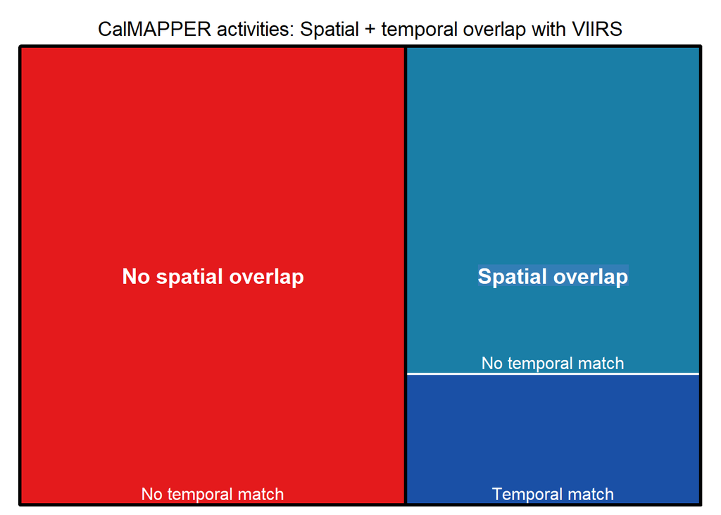

```r
# viz that breakdown
treemap::treemap(dat, index = c("spatial", 'temporal'), vSize = "values", type = "index",
                 align.labels=list(
        c("center", "center"),
        c("center", "bottom")
        ),
    overlap.labels = .5,
    inflate.labels = F,
    border.col=c("black","white"),
    border.lwds=c(3,2),
    fontsize.labels=c(15,12),
    palette = 'Set1',
    title = "CalMAPPER activities: Spatial + temporal overlap with VIIRS")
```